# Colab vscode 한글 환경설정

```python
# # colab
# # 런타임 다시시작을 해야 한글폰트가 적용 됩니다.
# !sudo apt-get install -y fonts-nanum
# !sudo fc-cache -fv
# !rm ~/.cache/matplotlib -rf
```

```python
# vscdoe
#패키지를 불러옵니다.
import matplotlib as mpl
import platform

#주피터 노트북내에 그림을 표시 합니다.
%matplotlib inline

my_platform = platform.system()
# 폰트 설정
if my_platform == 'Linux':
  mpl.rc('font', family='NanumBarunGothic')
elif my_platform == 'Windows':
  mpl.rc('font', family='Malgun Gothic')
elif my_platform == 'Darwin':
  mpl.rc('font', family='AppleGothic')

#그래프의 폰트를 선명하게 출력합니다.
from IPython.display import set_matplotlib_formats
set_matplotlib_formats('retina')

# 그래프 음수값 깨짐 방지
mpl.rc('axes', unicode_minus=False)
```

# 데이터시각화(범주vs연속/matplotlib)

## matplotlib

### 비교 분석

#### 막대그래프

- X : 범주형 데이터
- Y : 연속형 데이터

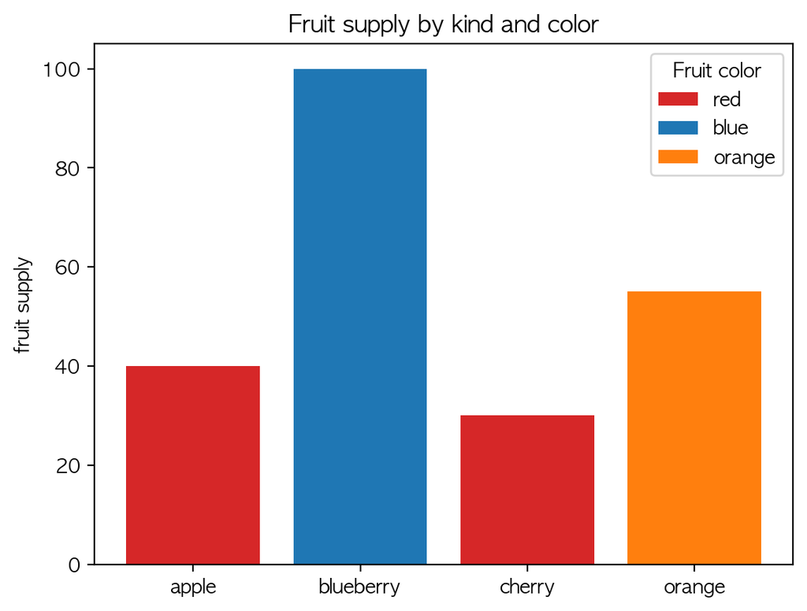

```python
import matplotlib.pyplot as plt

fig, ax = plt.subplots()

fruits = ['apple', 'blueberry', 'cherry', 'orange']
counts = [40, 100, 30, 55]
bar_labels = ['red', 'blue', '_red', 'orange'] # _red : 이미 존재하는 red에 포함
bar_colors = ['tab:red', 'tab:blue', 'tab:red', 'tab:orange']

ax.bar(fruits, counts, label=bar_labels, color=bar_colors)

ax.set_ylabel('fruit supply')
ax.set_title('Fruit supply by kind and color')
ax.legend(title='Fruit color')

plt.show()
```

#### 라인차트

- X : 연속형(시계열)
- Y : 연속형

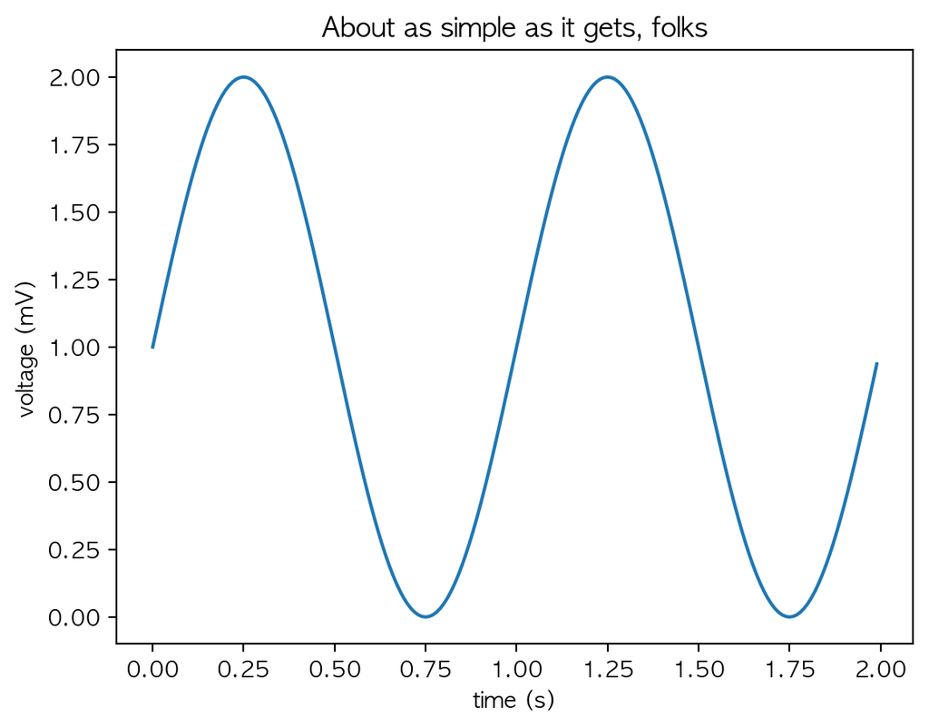

```python
import matplotlib.pyplot as plt
import numpy as np

# Data for plotting
t = np.arange(0.0, 2.0, 0.01)
s = 1 + np.sin(2 * np.pi * t)

fig, ax = plt.subplots()
ax.plot(t, s)

ax.set(xlabel='time (s)', ylabel='voltage (mV)',
       title='About as simple as it gets, folks')
plt.show()
```

### 구성분석

#### 파이차트

X : 연속형

[output not shown]

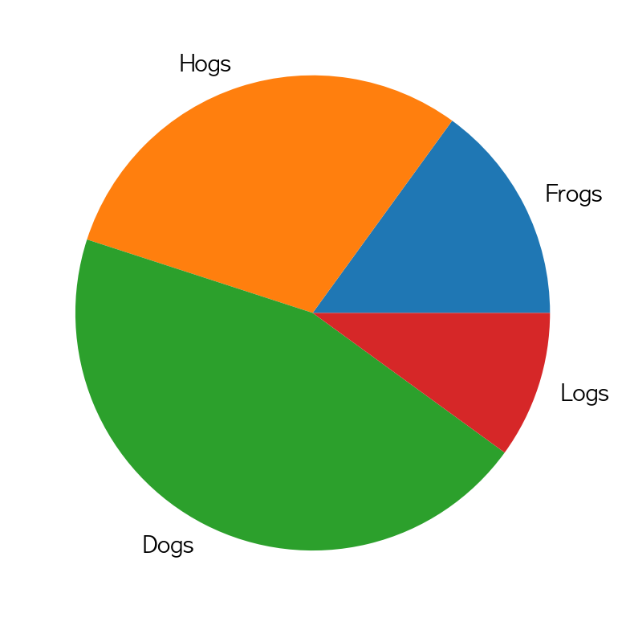

```python
import matplotlib.pyplot as plt
labels = ['Frogs', 'Hogs', 'Dogs', 'Logs']
sizes = [15, 30, 45, 10]

fig, ax = plt.subplots()
ax.pie(sizes, labels=labels)
```

#### 히트맵

- X : 범주형
- Y : 범주형
- value : 연속형

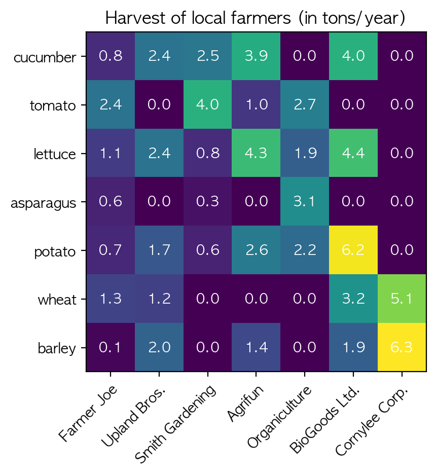

```python
import numpy as np
import matplotlib
import matplotlib as mpl
import matplotlib.pyplot as plt

vegetables = ["cucumber", "tomato", "lettuce", "asparagus",
              "potato", "wheat", "barley"]
farmers = ["Farmer Joe", "Upland Bros.", "Smith Gardening",
           "Agrifun", "Organiculture", "BioGoods Ltd.", "Cornylee Corp."]

harvest = np.array([[0.8, 2.4, 2.5, 3.9, 0.0, 4.0, 0.0],
                    [2.4, 0.0, 4.0, 1.0, 2.7, 0.0, 0.0],
                    [1.1, 2.4, 0.8, 4.3, 1.9, 4.4, 0.0],
                    [0.6, 0.0, 0.3, 0.0, 3.1, 0.0, 0.0],
                    [0.7, 1.7, 0.6, 2.6, 2.2, 6.2, 0.0],
                    [1.3, 1.2, 0.0, 0.0, 0.0, 3.2, 5.1],
                    [0.1, 2.0, 0.0, 1.4, 0.0, 1.9, 6.3]])


fig, ax = plt.subplots()
im = ax.imshow(harvest)

# Show all ticks and label them with the respective list entries
ax.set_xticks(np.arange(len(farmers)), labels=farmers)
ax.set_yticks(np.arange(len(vegetables)), labels=vegetables)

# Rotate the tick labels and set their alignment.
plt.setp(ax.get_xticklabels(), rotation=45, ha="right",
         rotation_mode="anchor")

# Loop over data dimensions and create text annotations.
for i in range(len(vegetables)):
    for j in range(len(farmers)):
        text = ax.text(j, i, harvest[i, j],
                       ha="center", va="center", color="w")

ax.set_title("Harvest of local farmers (in tons/year)")
fig.tight_layout() # 재정렬
plt.show()
```

### 관계분석

#### 스케터 차트

- X : 연속형
- Y : 연속형
- 원사이즈 : 연속형

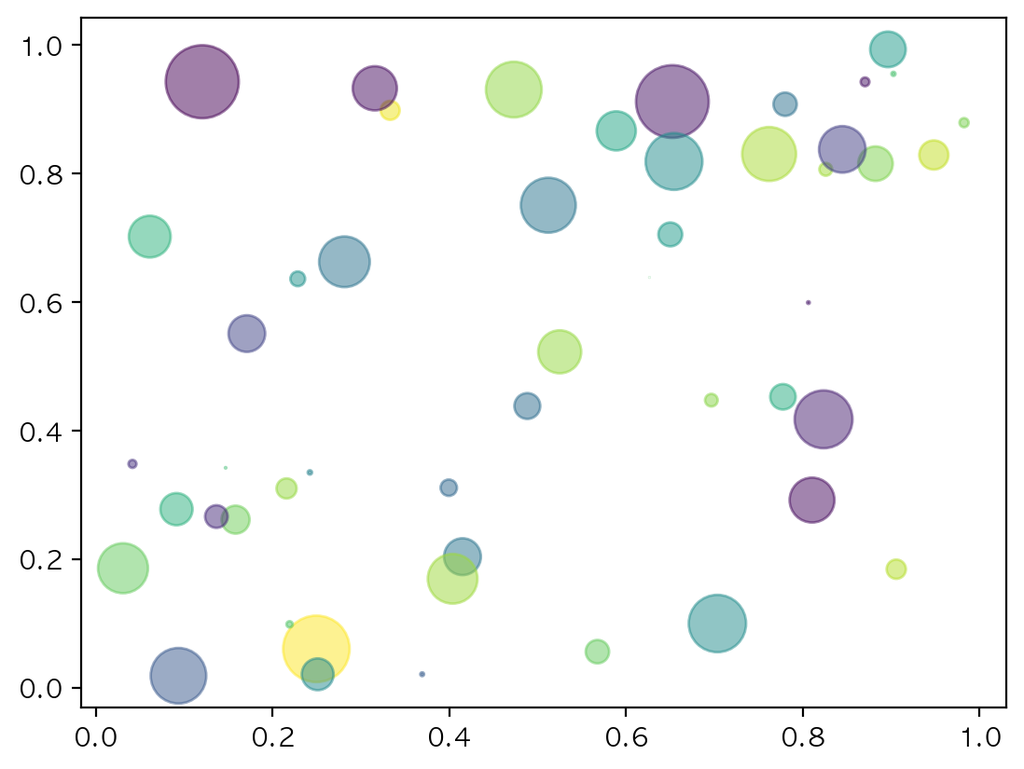

```python
import numpy as np
import matplotlib.pyplot as plt

N = 50
x = np.random.rand(N) # 랜덤한 값 50개
y = np.random.rand(N) # 랜덤한 값 50개
colors = np.random.rand(N) # 랜덤한 값 50개
area = (30 * np.random.rand(N))**2  # 0 to 15 point radii

plt.scatter(x, y, s=area, c=colors, alpha=0.5) # s : 원 사이즈 , c : 색상, alpha : 투명도
plt.show()
```

### 분포 분석

#### 히스토그램

- X, Y : 연속형

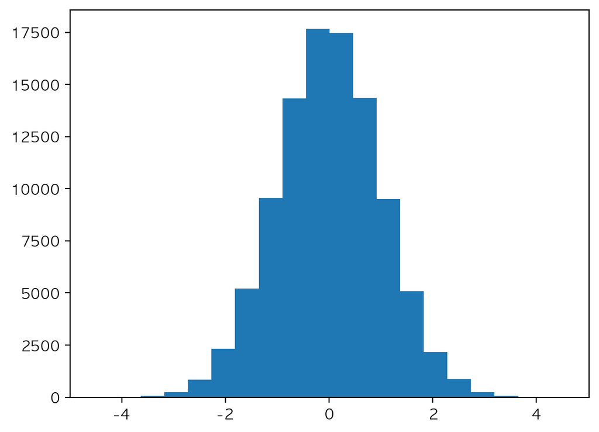

```python
import matplotlib.pyplot as plt
import numpy as np
from matplotlib import colors
from matplotlib.ticker import PercentFormatter

# Create a random number generator with a fixed seed for reproducibility
rng = np.random.default_rng(19680801)

N_points = 100000
n_bins = 20

# Generate two normal distributions
dist1 = rng.standard_normal(N_points) # 정규분포데이터 생성
fig, axs = plt.subplots()

# We can set the number of bins with the *bins* keyword argument.
axs.hist(dist1, bins=n_bins)
```

#### 박스플롯, 바이올린 플롯

- X,Y : 연속형

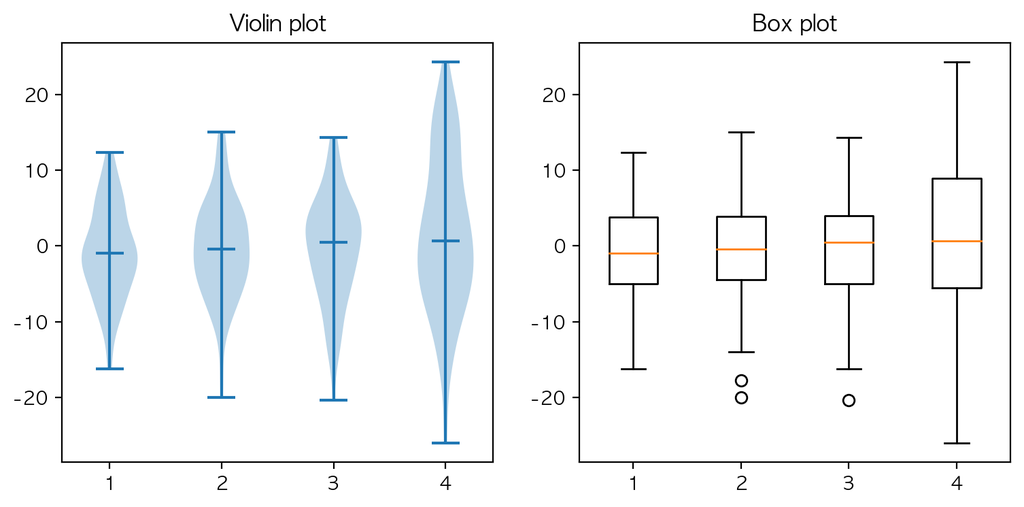

```python
import matplotlib.pyplot as plt
import numpy as np

fig, axs = plt.subplots(nrows=1, ncols=2, figsize=(9, 4))

# 100개의 배열을 가지는 데이터 그룹 4개 생성
all_data = [np.random.normal(0, std, 100) for std in range(6, 10)]

# plot violin plot
axs[0].violinplot(all_data,
                  showmeans=False,
                  showmedians=True)
axs[0].set_title('Violin plot')

# plot box plot
axs[1].boxplot(all_data)
axs[1].set_title('Box plot')

plt.show()
```

# matplotlib vs seaborn vs plotly

## matplotlib

- 가장 먼저 생긴 시각화 라이브러리
- seaborn도 matplotlib 기반으로 만들어짐
- 그래프에 X,Y에 리스트(배열)로 넣어줘야 한다.

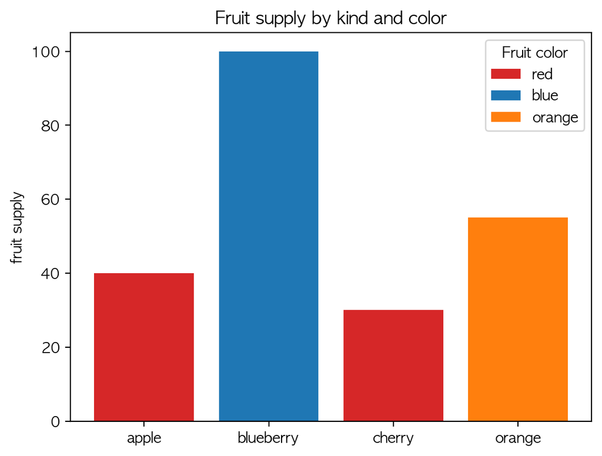

```python
import matplotlib.pyplot as plt

fig, ax = plt.subplots()

fruits = ['apple', 'blueberry', 'cherry', 'orange']
counts = [40, 100, 30, 55]
bar_labels = ['red', 'blue', '_red', 'orange'] # _red : 이미 존재하는 red에 포함
bar_colors = ['tab:red', 'tab:blue', 'tab:red', 'tab:orange']

ax.bar(fruits, counts, label=bar_labels, color=bar_colors)

ax.set_ylabel('fruit supply')
ax.set_title('Fruit supply by kind and color')
ax.legend(title='Fruit color')

plt.show()
```

## seaborn

- matplotlib 기반으로 만들어졌다.
- pandas에서 활용하는 데이터프레임 데이터타입의 데이터를 시각화하는데 유리

```python
#!pip install seaborn
import seaborn as sns
df = sns.load_dataset("penguins")
df.head()
```

|  | species | island | bill_length_mm | bill_depth_mm | flipper_length_mm | body_mass_g | sex |
| --- | --- | --- | --- | --- | --- | --- | --- |
| 0 | Adelie | Torgersen | 39.1 | 18.7 | 181.0 | 3750.0 | Male |
| 1 | Adelie | Torgersen | 39.5 | 17.4 | 186.0 | 3800.0 | Female |
| 2 | Adelie | Torgersen | 40.3 | 18.0 | 195.0 | 3250.0 | Female |
| 3 | Adelie | Torgersen | NaN | NaN | NaN | NaN | NaN |
| 4 | Adelie | Torgersen | 36.7 | 19.3 | 193.0 | 3450.0 | Female |

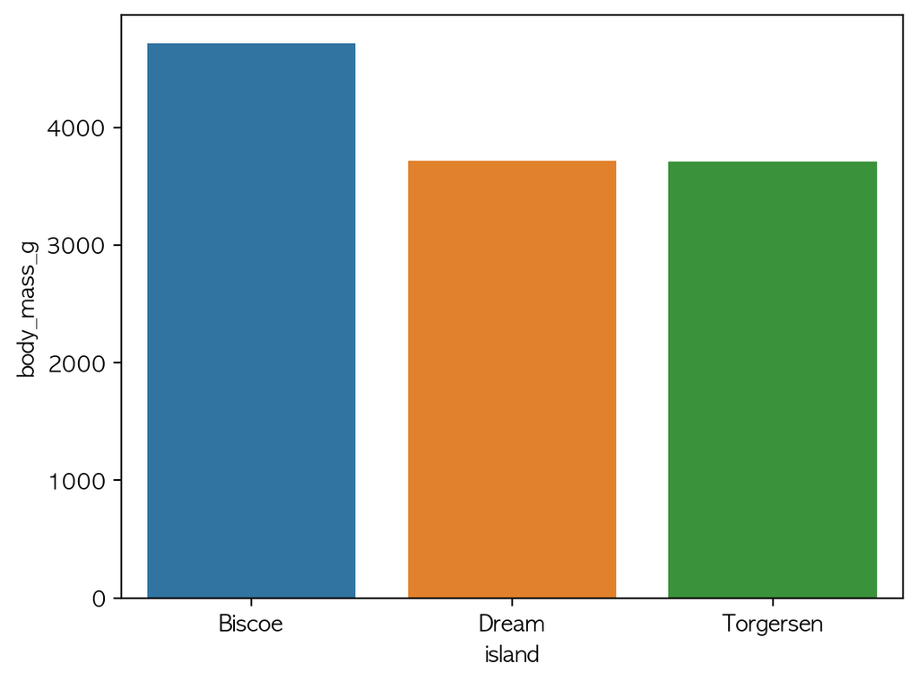

```python
g1 = df[['island', 'body_mass_g']].groupby('island').mean()
sns.barplot(data=g1, x=g1.index, y="body_mass_g")
```

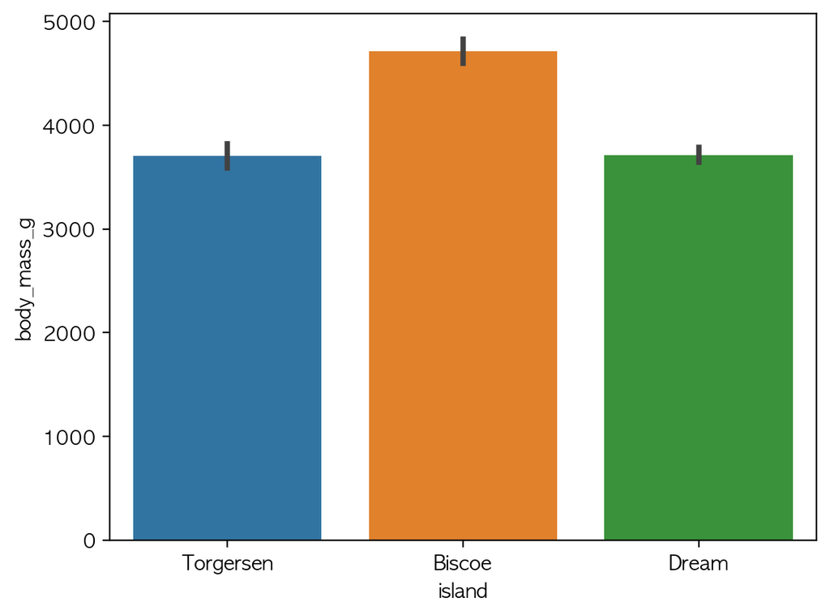

```python
sns.barplot(data=df, x="island", y="body_mass_g")
```

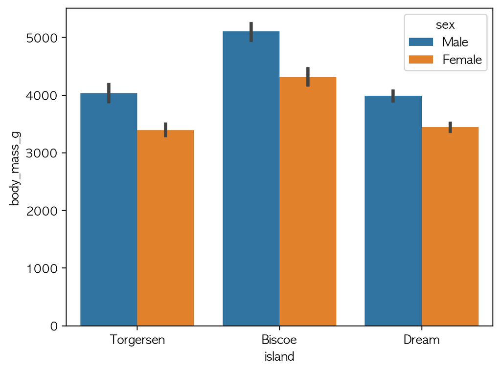

```python
sns.barplot(data=df, x="island", y="body_mass_g", hue="sex")
```

## plotly

- 인터렉티브하다.
- 배열, 데이터프레임 가능

```python
#!pip install plotly
import plotly.express as px
data_canada = px.data.gapminder().query("country == 'Canada'")
data_canada.head()
```

|  | country | continent | year | lifeExp | pop | gdpPercap | iso_alpha | iso_num |
| --- | --- | --- | --- | --- | --- | --- | --- | --- |
| 240 | Canada | Americas | 1952 | 68.75 | 14785584 | 11367.16112 | CAN | 124 |
| 241 | Canada | Americas | 1957 | 69.96 | 17010154 | 12489.95006 | CAN | 124 |
| 242 | Canada | Americas | 1962 | 71.30 | 18985849 | 13462.48555 | CAN | 124 |
| 243 | Canada | Americas | 1967 | 72.13 | 20819767 | 16076.58803 | CAN | 124 |
| 244 | Canada | Americas | 1972 | 72.88 | 22284500 | 18970.57086 | CAN | 124 |

```python
fig = px.bar(data_canada, x='year', y='pop')
fig.show()
```

```python
import plotly.express as px
df = px.data.iris()
df.head()
```

|  | sepal_length | sepal_width | petal_length | petal_width | species | species_id |
| --- | --- | --- | --- | --- | --- | --- |
| 0 | 5.1 | 3.5 | 1.4 | 0.2 | setosa | 1 |
| 1 | 4.9 | 3.0 | 1.4 | 0.2 | setosa | 1 |
| 2 | 4.7 | 3.2 | 1.3 | 0.2 | setosa | 1 |
| 3 | 4.6 | 3.1 | 1.5 | 0.2 | setosa | 1 |
| 4 | 5.0 | 3.6 | 1.4 | 0.2 | setosa | 1 |

```python
fig = px.scatter(df, x="sepal_width", y="sepal_length", color="species",
                 size='petal_length', hover_data=['petal_width'])
fig.show()
```

```python
import plotly.graph_objects as go
fig = go.Figure([go.Bar(x=['giraffes', 'orangutans', 'monkeys'], y=[20, 14, 23])])
fig.show()
```

# 실습

1. '최종주문요일'에 대한 횟수 시각화(마지막으로 주문한 요일의 횟수)
2. 성별에 따른 '최종주문요일'에 대한 횟수 시각화(마지막으로 주문한 요일의 횟수)
3. '최종주문일자'와 '가입월' 데이터 분포 시각화
4. 성별에 따른 '최종주문월'에 대한 '총순수이익' 시각화
5. 성별에 따른 나이 분포 시각
6. '유입경로'별 '총판매액' 비교

```python
import pandas as pd

df = pd.read_csv('https://raw.githubusercontent.com/jin0choi1216/dataset/main/%40preprocessing_data_member01.csv', index_col = 0)
df.head()
```

|  | ID | 총구매수량_x | 기타품목구매비율 | 수저류구매비율 | 실링구매비율 | 용기류구매비율 | 위생용품구매비율 | 총구매횟수 | 총판매액 | 총할인금액 | ... | 최종주문연도 | 최종주문월 | 최종주문일자 | 최종주문요일 | 최종주문시간 | 회원가입일(clean) | 가입연도 | 가입월 | 가입일자 | 가입요일 |
| --- | --- | --- | --- | --- | --- | --- | --- | --- | --- | --- | --- | --- | --- | --- | --- | --- | --- | --- | --- | --- | --- |
| 0 | 100304734@n | 1.0 | 0.0 | 0.0 | 0.0 | 1.0 | 0.0 | 1 | 103300 | 0 | ... | 2019.0 | 5.0 | 9.0 | Thursday | 14.0 | 2019-05-09 00:00:00 | 2019.0 | 5.0 | 9.0 | Thursday |
| 1 | 1003409866@k | 62.0 | 0.0 | 0.0 | 0.0 | 1.0 | 0.0 | 18 | 4303880 | 379040 | ... | 2019.0 | 5.0 | 28.0 | Tuesday | 16.0 | 2019-01-07 00:00:00 | 2019.0 | 1.0 | 7.0 | Monday |
| 2 | 100381931@n | 5.0 | 0.0 | 0.0 | 0.0 | 0.0 | 1.0 | 3 | 71050 | 15000 | ... | 2019.0 | 2.0 | 10.0 | Sunday | 21.0 | 2018-10-31 00:00:00 | 2018.0 | 10.0 | 31.0 | Wednesday |
| 3 | 1004498382@k | 1.0 | 0.0 | 0.0 | 0.0 | 1.0 | 0.0 | 1 | 76400 | 14500 | ... | 2019.0 | 1.0 | 9.0 | Wednesday | 12.0 | 2019-01-09 00:00:00 | 2019.0 | 1.0 | 9.0 | Wednesday |
| 4 | 1004547839@k | 4.0 | 1.0 | 0.0 | 0.0 | 0.0 | 0.0 | 1 | 360800 | 53400 | ... | 2019.0 | 1.0 | 9.0 | Wednesday | 13.0 | 2019-01-09 00:00:00 | 2019.0 | 1.0 | 9.0 | Wednesday |

5 rows × 35 columns

```python
df.columns
```

```
Index(['ID', '총구매수량_x', '기타품목구매비율', '수저류구매비율', '실링구매비율', '용기류구매비율', '위생용품구매비율',
       '총구매횟수', '총판매액', '총할인금액', '총순수이익', '나이', '사용가능 적립금', '성별', '최종접속일',
       '최종주문일', '유입경로', '유입기기', '회원 가입일', '사업자구분', '회원구분', '지역', '세부지역', '주소',
       '최종주문일(clean)', '최종주문연도', '최종주문월', '최종주문일자', '최종주문요일', '최종주문시간',
       '회원가입일(clean)', '가입연도', '가입월', '가입일자', '가입요일'],
      dtype='object')
```

## 1. '최종주문요일'에 대한 횟수 시각화(마지막으로 주문한 요일의 횟수)

```python
df1 = df.groupby(['최종주문요일']).size().sort_values(ascending=False)
df1.index
```

```
Index(['Monday', 'Wednesday', 'Tuesday', 'Thursday', 'Friday', 'Sunday',
       'Saturday'],
      dtype='object', name='최종주문요일')
```

```
No artists with labels found to put in legend.  Note that artists whose label start with an underscore are ignored when legend() is called with no argument.
```

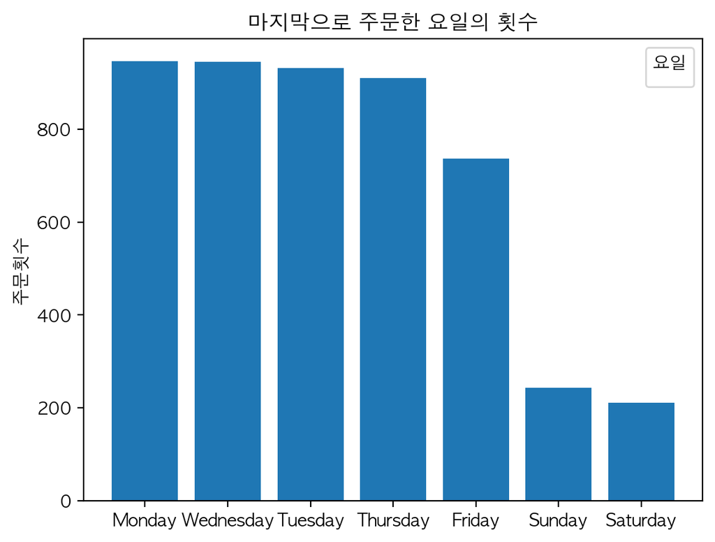

```python
import matplotlib.pyplot as plt

fig, ax = plt.subplots()

최종주문요일 = df1.index
counts = df1.values
#bar_labels = ['red', 'blue', '_red', 'orange']
#bar_colors = ['tab:red', 'tab:blue', 'tab:red', 'tab:orange']

ax.bar(최종주문요일, counts)#, label=bar_labels, color=bar_colors)

ax.set_ylabel('주문횟수')
ax.set_title('마지막으로 주문한 요일의 횟수')
ax.legend(title='요일')

plt.show()
```

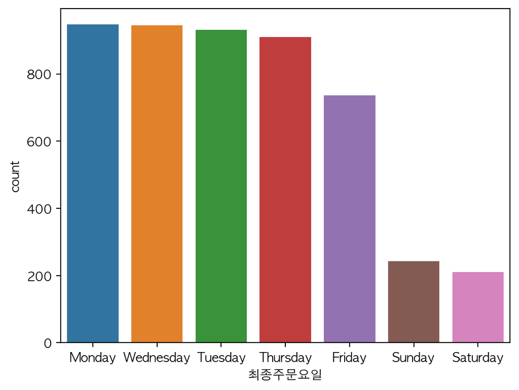

```python
# 1. '최종주문요일'에 대한 주문횟수 시각화(마지막으로 주문한 각 요일의 횟수)
import seaborn as sns
q1 = df['최종주문요일'].value_counts().to_frame()
sns.barplot(data=q1, x=q1.index, y='count')
```

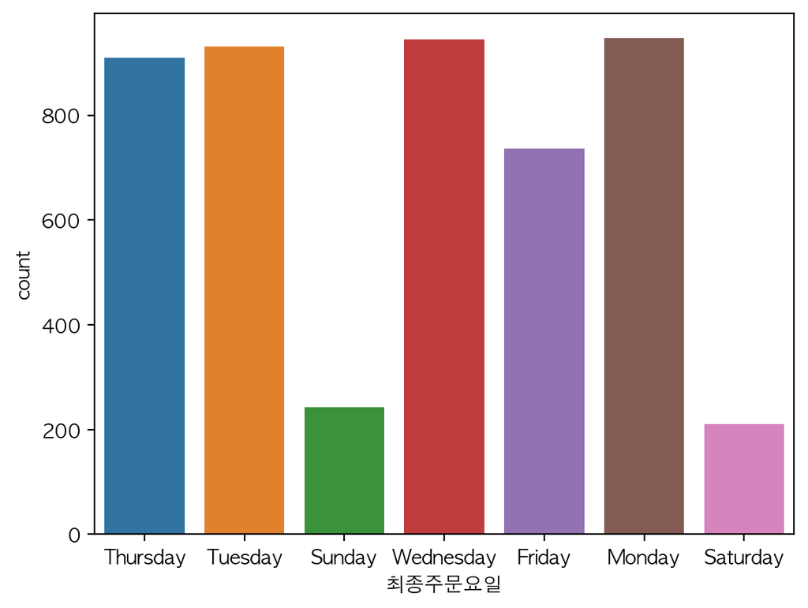

```python
sns.countplot(x=df["최종주문요일"])
```

```
<BarContainer object of 7 artists>
```

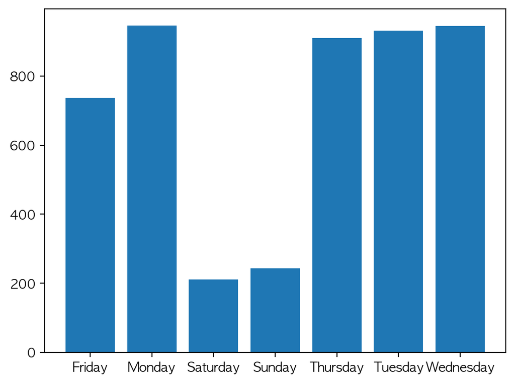

```python
import matplotlib.pyplot as plt
d1 = df[['최종주문요일','총구매횟수']].groupby('최종주문요일').count().sort_values('최종주문요일')
plt.bar(d1.index, d1['총구매횟수'])
```

## 2. 성별에 따른 '최종주문요일'에 대한 횟수 시각화(마지막으로 주문한 요일의 횟수)

```python
from os import name
df2 = df[['성별','최종주문요일']]
df2_m = df2.query('성별 == "남자"').groupby('최종주문요일').count()
df2_f = df2.query('성별 == "여자"').groupby('최종주문요일').count()
df2 = pd.merge(df2_m, df2_f, on='최종주문요일')
df2_m
# df2_total = df2
```

| 최종주문요일 | 성별 |
| --- | --- |
| Friday | 676 |
| Monday | 871 |
| Saturday | 197 |
| Sunday | 222 |
| Thursday | 850 |
| Tuesday | 861 |
| Wednesday | 883 |

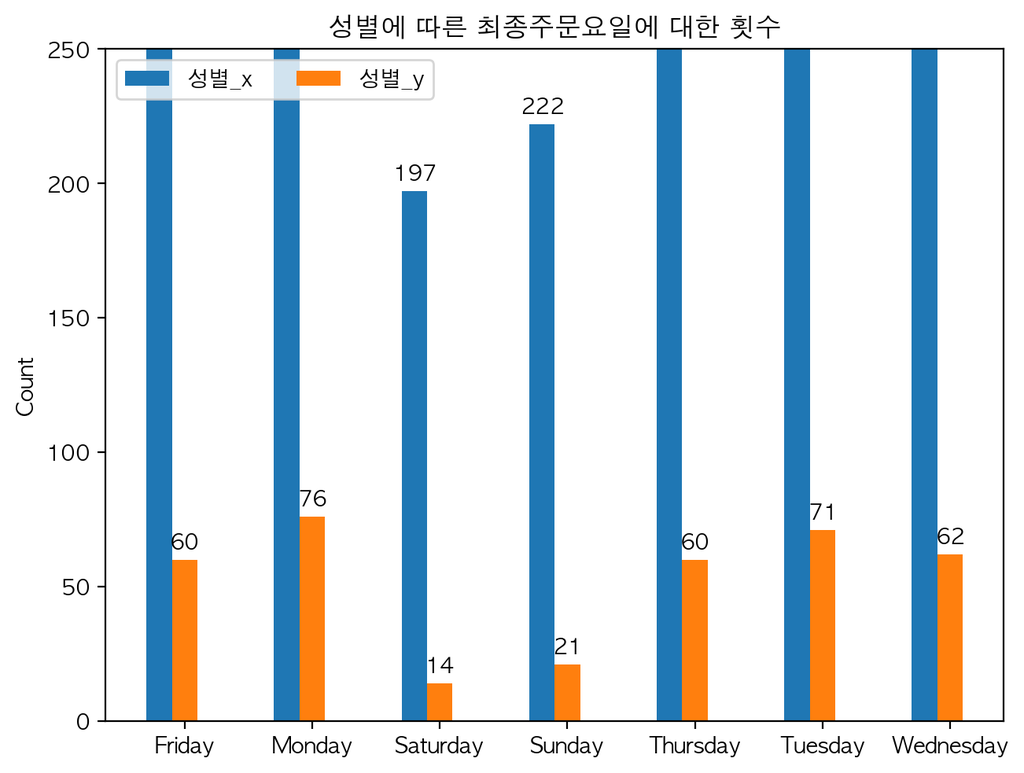

```python
# data from https://allisonhorst.github.io/palmerpenguins/

import matplotlib.pyplot as plt
import numpy as np

species = df2.index
#penguin_means = df2

x = np.arange(len(species))  # the label locations
width = 0.2  # the width of the bars
multiplier = 0

fig, ax = plt.subplots(layout='constrained')

for attribute, counts in df2.items():
    offset = width * multiplier
    rects = ax.bar(x + offset, counts, width, label=attribute)
    ax.bar_label(rects, padding=3)
    multiplier += 1

# Add some text for labels, title and custom x-axis tick labels, etc.
ax.set_ylabel('Count')
ax.set_title('성별에 따른 최종주문요일에 대한 횟수')
ax.set_xticks(x + width, species)
ax.legend(loc='upper left', ncols=3)
ax.set_ylim(0, 250)

plt.show()
```

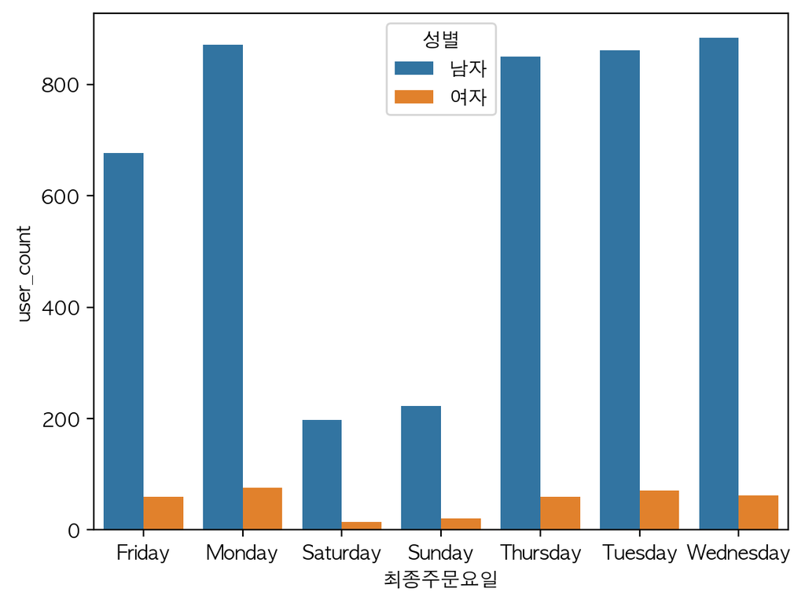

```python
# 2. 성별에 따른 '최종주문요일'에 대한 횟수 시각화(마지막으로 주문한 요일의 횟수)
q1 = df[['성별','최종주문요일','ID']].groupby(['성별', '최종주문요일'], as_index = False).count()
q1.rename(columns = {'ID' : 'user_count'}, inplace = True)
sns.barplot(data=q1, x="최종주문요일", y="user_count", hue="성별")
```

## 3. '최종주문일자'와 '가입월' 데이터 분포 시각화

```python
#!pip install nbformat
```

```python
# 3. '최종주문일자'와 '가입월' 데이터 분포 시각화
import plotly.express as px
fig = px.histogram(df, x="최종주문일자")
fig.show()
```

```python
fig = px.histogram(df, x="가입월")
fig.show()
```

## 4. 성별에 따른 '최종주문월'에 대한 '총순수이익' 시각화

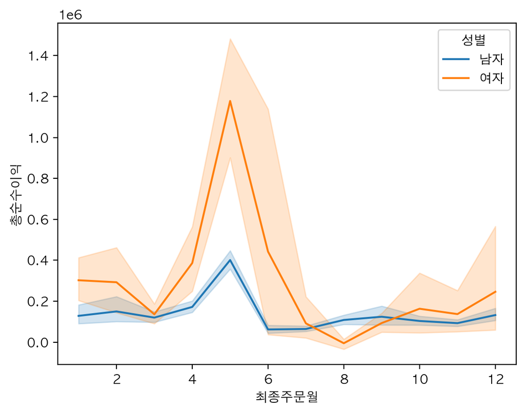

```python
# 4. 성별에 따른 '최종주문월'에 대한 '총순수이익' 시각화
sns.lineplot(data=df, x="최종주문월", y="총순수이익", hue="성별")
```

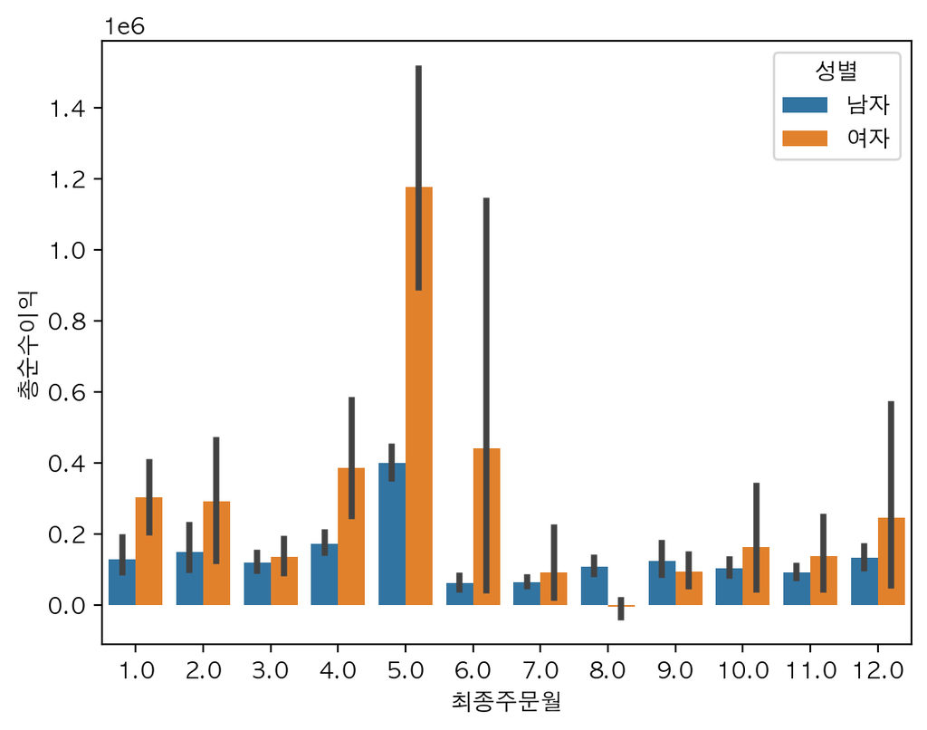

```python
sns.barplot(data=df, x="최종주문월", y="총순수이익", hue="성별")
```

## 5. 성별에 따른 나이 분포 시각

```python
df[['성별', '나이']]
```

|  | 성별 | 나이 |
| --- | --- | --- |
| 0 | 남자 | 47.0 |
| 1 | 남자 | 27.0 |
| 2 | 남자 | 41.0 |
| 3 | 남자 | 47.0 |
| 4 | 남자 | 47.0 |
| ... | ... | ... |
| 4931 | 남자 | 45.0 |
| 4932 | 남자 | 32.0 |
| 4933 | 여자 | 40.0 |
| 4934 | 남자 | 45.0 |
| 4935 | 남자 | 46.0 |

4924 rows × 2 columns

```python
import plotly.express as px
fig = px.violin(df, y="나이", color="성별")
fig.show()
```

## 6. '유입경로'별 '총판매액' 비교

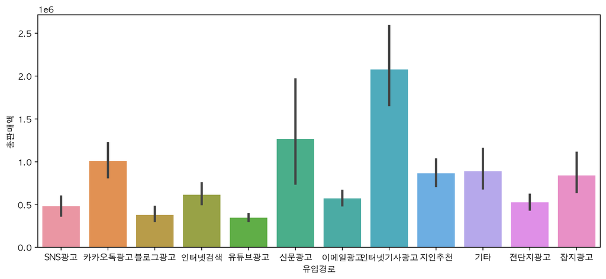

```python
df[['유입경로', '총판매액']]
plt.figure(figsize = (12,5))
sns.barplot(data=df, x='유입경로', y='총판매액')
```

# 과제

## 데이터셋 & 샘플

```python
df = pd.read_csv('0914_shopping_mall.csv',index_col=0)
df['price'] = df['item_price'] * df['quantity']
df.head()
```

|  | detail_id | transaction_id | item_id | quantity | payment_date | customer_id | customer_name | registration_date | email | gender | age | birth | pref | item_name | item_price | price |
| --- | --- | --- | --- | --- | --- | --- | --- | --- | --- | --- | --- | --- | --- | --- | --- | --- |
| 0 | 0 | T0000000113 | S005 | 1 | 2019-02-01 01:36:57 | PL563502 | 김태경 | 2019-01-07 14:34 | imoto_yoshimasa@example.com | M | 30 | 1989-07-15 | 대전광역시 | PC-E | 210000 | 210000 |
| 1 | 1 | T0000000114 | S001 | 1 | 2019-02-01 01:37:23 | HD678019 | 김영웅 | 2019-01-27 18:00 | mifune_rokurou@example.com | M | 73 | 1945-11-29 | 서울특별시 | PC-A | 50000 | 50000 |
| 2 | 2 | T0000000115 | S003 | 1 | 2019-02-01 02:34:19 | HD298120 | 김강현 | 2019-01-11 8:16 | yamane_kogan@example.com | M | 42 | 1977-05-17 | 광주광역시 | PC-C | 120000 | 120000 |
| 3 | 3 | T0000000116 | S005 | 1 | 2019-02-01 02:47:23 | IK452215 | 김주한 | 2019-01-10 5:07 | ikeda_natsumi@example.com | F | 47 | 1972-03-17 | 인천광역시 | PC-E | 210000 | 210000 |
| 4 | 4 | T0000000117 | S002 | 2 | 2019-02-01 04:33:46 | PL542865 | 김영빈 | 2019-01-25 6:46 | kurita_kenichi@example.com | M | 74 | 1944-12-17 | 광주광역시 | PC-B | 85000 | 170000 |

```python
# 지역별 매출?
q1 =df[['pref','price']].\
    groupby('pref',as_index=False).\
    sum().sort_values(by='price',ascending=False)
# ,as_index=False -> 그래프 그릴 때 인덱스 사용
```

```python
import plotly.express as px
fig = px.bar(q1, x='pref',y='price', color = 'pref')
fig.show()
```

```python
fig = px.pie(df, values='price', names='pref', title='지역별 매출?')
fig.update_traces(textposition='inside', textinfo='label+percent')
fig.show()
```

```python
# 성별 상품 선호도?
q2 = df[['gender', 'quantity', 'item_name']]
q2g = q2.groupby(['item_name', 'gender'], as_index = False).sum()
```

```python
fig = px.bar(q2g, x="item_name", y="quantity", color="gender", barmode="group")
fig.show()
```

```python
df = pd.read_csv('0914_shopping_mall.csv',index_col=0)
df['price'] = df['quantity']*df['item_price']
df['payment_date'] = pd.to_datetime(df['payment_date'],format='%Y-%m-%d %H:%M:%S')
df.head(2)
```

|  | detail_id | transaction_id | item_id | quantity | payment_date | customer_id | customer_name | registration_date | email | gender | age | birth | pref | item_name | item_price | price |
| --- | --- | --- | --- | --- | --- | --- | --- | --- | --- | --- | --- | --- | --- | --- | --- | --- |
| 0 | 0 | T0000000113 | S005 | 1 | 2019-02-01 01:36:57 | PL563502 | 김태경 | 2019-01-07 14:34 | imoto_yoshimasa@example.com | M | 30 | 1989-07-15 | 대전광역시 | PC-E | 210000 | 210000 |
| 1 | 1 | T0000000114 | S001 | 1 | 2019-02-01 01:37:23 | HD678019 | 김영웅 | 2019-01-27 18:00 | mifune_rokurou@example.com | M | 73 | 1945-11-29 | 서울특별시 | PC-A | 50000 | 50000 |

```python
df1 = df[['gender','item_name','quantity']]\
    .groupby(['gender','item_name'], as_index=False)\
    .sum()
df1
```

|  | gender | item_name | quantity |
| --- | --- | --- | --- |
| 0 | F | PC-A | 1526 |
| 1 | F | PC-B | 879 |
| 2 | F | PC-C | 520 |
| 3 | F | PC-D | 445 |
| 4 | F | PC-E | 893 |
| 5 | M | PC-A | 1517 |
| 6 | M | PC-B | 906 |
| 7 | M | PC-C | 502 |
| 8 | M | PC-D | 455 |
| 9 | M | PC-E | 929 |

```python
import plotly.express as px

fig = px.bar(df1, x="item_name", y="quantity", color="gender", barmode="group")
fig.show()
```

## 2. 지역별 성별 당 총 소비 가격

```python
df2 = df[['gender', 'pref','price']].groupby(['gender', 'pref'], as_index=False).sum()
df2
```

|  | gender | pref | price |
| --- | --- | --- | --- |
| 0 | F | 광주광역시 | 43085000 |
| 1 | F | 대구광역시 | 48710000 |
| 2 | F | 대전광역시 | 85450000 |
| 3 | F | 부산광역시 | 61130000 |
| 4 | F | 서울특별시 | 98725000 |
| 5 | F | 울산광역시 | 40620000 |
| 6 | F | 인천광역시 | 103325000 |
| 7 | M | 광주광역시 | 38855000 |
| 8 | M | 대구광역시 | 52080000 |
| 9 | M | 대전광역시 | 97755000 |
| 10 | M | 부산광역시 | 64105000 |
| 11 | M | 서울특별시 | 89060000 |
| 12 | M | 울산광역시 | 44030000 |
| 13 | M | 인천광역시 | 104205000 |

```python
fig = px.bar(df2, x="pref", y="price", color="gender", barmode="group")
fig.show()
```

```python
# https://youngwonhan-family.tistory.com/entry/%EA%B5%AD%EB%82%B4-%EC%8B%9C%EB%8F%84%EB%B3%84-%EC%BD%94%EB%A1%9C%EB%82%98-19-%ED%99%95%EC%A7%84-%EC%A0%95%EB%B3%B4-Plotly-%EA%B3%B5%EA%B0%84%EC%A0%95%EB%B3%B4-%EB%8B%A8%EA%B3%84%EA%B5%AC%EB%B6%84%EB%8F%84-choropleth-map
import json
with open('korea_geojson2.geojson', encoding='UTF-8') as f:
    data = json.load(f)

for x in data['features']:
    x['id'] = x['properties']['CTP_KOR_NM']

for idx, _ in enumerate(data['features']):
    print(data['features'][idx]['id'])
```

```
강원도
경기도
경상남도
경상북도
광주광역시
대구광역시
대전광역시
부산광역시
서울특별시
세종특별자치시
울산광역시
인천광역시
전라남도
전라북도
제주특별자치도
충청남도
충청북도
```

```python
df2_m = df2.query('gender == "M"')
df2_f = df2.query('gender == "F"')
df2_m
```

|  | gender | pref | price |
| --- | --- | --- | --- |
| 7 | M | 광주광역시 | 38855000 |
| 8 | M | 대구광역시 | 52080000 |
| 9 | M | 대전광역시 | 97755000 |
| 10 | M | 부산광역시 | 64105000 |
| 11 | M | 서울특별시 | 89060000 |
| 12 | M | 울산광역시 | 44030000 |
| 13 | M | 인천광역시 | 104205000 |

```python
fig = px.choropleth_mapbox(
   df2_m,
   geojson=data,
   locations='pref',
   color='price',
   color_continuous_scale=px.colors.sequential.Redor,

   mapbox_style="carto-positron",
   zoom=5.5,
   center = {"lat": 35.757981, "lon": 127.661132},
   opacity=0.6,
   labels={'price':'남성 소비 금액'}
)
fig.update_layout(margin={"r":0,"t":0,"l":0,"b":0})
fig.show()
```

```python
fig = px.choropleth_mapbox(
   df2_f,
   geojson=data,
   locations='pref',
   color='price',
   color_continuous_scale=px.colors.sequential.Redor,

   mapbox_style="carto-positron",
   zoom=5.5,
   center = {"lat": 35.757981, "lon": 127.661132},
   opacity=0.6,
   labels={'price':'여성 소비 금액'}
)
fig.update_layout(margin={"r":0,"t":0,"l":0,"b":0})
fig.show()
```

## 3. 월별 구매량

```python
df.head(2)
```

|  | detail_id | transaction_id | item_id | quantity | payment_date | customer_id | customer_name | registration_date | email | gender | age | birth | pref | item_name | item_price | price |
| --- | --- | --- | --- | --- | --- | --- | --- | --- | --- | --- | --- | --- | --- | --- | --- | --- |
| 0 | 0 | T0000000113 | S005 | 1 | 2019-02-01 01:36:57 | PL563502 | 김태경 | 2019-01-07 14:34 | imoto_yoshimasa@example.com | M | 30 | 1989-07-15 | 대전광역시 | PC-E | 210000 | 210000 |
| 1 | 1 | T0000000114 | S001 | 1 | 2019-02-01 01:37:23 | HD678019 | 김영웅 | 2019-01-27 18:00 | mifune_rokurou@example.com | M | 73 | 1945-11-29 | 서울특별시 | PC-A | 50000 | 50000 |

```python
import datetime

# df3 = df['payment_date'].dt.strftime('%Y%m').rename('payment_month')
# df3
df3 = pd.concat([df,
    df['payment_date'].dt.strftime('%Y%m').
    rename('payment_month')],axis=1)
df3.head(2)
```

|  | detail_id | transaction_id | item_id | quantity | payment_date | customer_id | customer_name | registration_date | email | gender | age | birth | pref | item_name | item_price | price | payment_month |
| --- | --- | --- | --- | --- | --- | --- | --- | --- | --- | --- | --- | --- | --- | --- | --- | --- | --- |
| 0 | 0 | T0000000113 | S005 | 1 | 2019-02-01 01:36:57 | PL563502 | 김태경 | 2019-01-07 14:34 | imoto_yoshimasa@example.com | M | 30 | 1989-07-15 | 대전광역시 | PC-E | 210000 | 210000 | 201902 |
| 1 | 1 | T0000000114 | S001 | 1 | 2019-02-01 01:37:23 | HD678019 | 김영웅 | 2019-01-27 18:00 | mifune_rokurou@example.com | M | 73 | 1945-11-29 | 서울특별시 | PC-A | 50000 | 50000 | 201902 |

```python
df3[['payment_month','price']].head(2)
```

|  | payment_month | price |
| --- | --- | --- |
| 0 | 201902 | 210000 |
| 1 | 201902 | 50000 |

```python
import plotly.express as px
fig = px.scatter(df3, x="payment_month", y="price"
                 , marginal_x="histogram", marginal_y="rug")
fig.show()
```